# Comparative Effects of Angiotensin-Converting Enzyme Inhibitors and Angiotensin Receptor Blockers on Response to a Physical Activity Intervention in Older Adults: Results From the Lifestyle Interventi

### Statistical Analysis

Two general approaches were used to compare outcomes among ACEi and ARB users. The first compared the LIFE randomized intervention arms, PA versus HE, among each medication group using interaction terms (2,5). This approach evaluated the effect of the PA intervention by medication group to determine whether there was a synergistic effect of medications with response to PA. The cohort was then separated by intervention assignment and multivariable logistic models were used to generate probabilities (propensity scores) of being treated with ACEis or ARBs conditional on baseline demographic and clinical characteristics of participants (Table 1). Using this probability, inverse probability of treatment weights (IPTW) were calculated for each participant, which are a commonly used approach to control for confounding (25–27). Covariate balance with IPTW was assessed using standardized differences (*SD*) where a value of less than or equal to 0.10 is suggestive of covariate balance between the two groups (28).

Table 1.

Baseline Characteristics Before and After Inverse Probability of Treatment Weighting Adjustment Among Angiotensin-Converting Enzyme Inhibitors (ACEis) and Angiotensin Receptor Blocker (ARBs) Users

| Characteristics | Medication use ACEi *N* = 496 (62.3%) | ARBs *N* = 300 (37.7%) | *p*-value | St. Diff.* |
| --- | --- | --- | --- | --- |
| Physical activity intervention | 249 (50.2%) | 142 (47.3%) | — | — |
| Age, mean (*SD*) | 78.9 (5.3) | 78.5 (5.1) | .344 | <0.00 |
| Female | 281 (56.7%) | 239 (79.7%) | <.001 | 0.02 |
| Race |  |  | <.001 |  |
| White | 383 (77.2%) | 197 (65.7%) |  |  |
| Black | 77 (15.5%) | 81 (27.0%) |  |  |
| Other | 36 (7.3%) | 22 (7.3%) |  |  |
| Education, ≥ high school | 331 (66.7%) | 197 (65.7%) | .758 | 0.02 |
| Systolic blood pressure, mean (SD) | 126.9 (18.5) | 129.7 (20.0) | .050 | 0.08 |
| Diastolic blood pressure, mean (*SD*) | 67.0 (10.4) | 68.2 (11.2) | .130 | 0.06 |
| Smoking |  |  | .856 |  |
| Never | 259 (52.2%) | 161 (53.7%) |  |  |
| Former | 224 (45.2%) | 130 (43.3%) |  |  |
| Current | 13 (2.6%) | 9 (3.0%) |  |  |
| Body mass index | 30.6 (5.6) | 32.0 (5.9) | <.001 | <0.00 |
| Hypertension | 440 (88.7%) | 283 (94.3%) | .008 | 0.10 |
| Cerebrovascular disease | 176 (35.5%) | 86 (28.7%) | .047 | <0.00 |
| Diabetes | 198 (39.9%) | 187 (37.7%) | .530 | <0.00 |
| Heart attack | 58 (11.7%) | 28 (9.3%) | .299 | <0.00 |
| Heart failure | 34 (6.9%) | 23 (7.7%) | .667 | <0.00 |
| Arthritis | 85 (17.1%) | 69 (23.0%) | .042 | 0.01 |
| Chronic lung disease | 30 (16.1%) | 51 (17.0%) | .748 | 0.01 |
| SPPB ≤7 | 225 (45.4%) | 131 (43.7%) | .641 | 0.01 |
| Number of antihypertensive drugs |  |  | .789 | <0.00 |
| 1 | 156 (31.5%) | 95 (32.3%) |  |  |
| 2 | 223 (45.0%) | 130 (43.3%) |  |  |
| 3+ | 117 (23.6%) | 73 (24.3%) |  |  |
| Self-rated overall health |  |  | .507 | 0.01 |
| Poor | 29 (5.9%) | 10 (3.3%) |  |  |
| Fair | 114 (23.0%) | 72 (24.0%) |  |  |
| Good | 258 (52.0%) | 159 (53.0%) |  |  |
| Very good–excellent | 95 (19.1%) | 59 (19.7%) |  |  |
| Moderate activity (daily average), mean (*SD*) |  |  |  |  |
| Minutes | 25.1 (24.0) | 26.1 (20.3) | .577 | 0.10 |
| Steps | 916.6 (1,126.8) | 870.1 (924.8) | .573 | 0.01 |
| Gait speed (m/s), mean (*SD*) | 0.81 (0.17) | 0.81 (0.15) | .664 | 0.02 |
| Cognitive assessment (3*MSE*), mean (*SD*) | 91.5 (5.5) | 91.5 (5.6) | .970 | 0.05 |
| Session attendance | 64% | 67% | .112 | <0.00 |

*Standardized differences were assessed using weights generated from the propensity score model. A St. Diff. > 0.10 is considered a significant difference between groups. ACEi = angiotensin-converting enzyme inhibitors; ARB = angiotensin receptor blockers; IPTW = inverse probability of treatment weight.; 3MSE = Modified Mini-Mental State Examiniation; SD = standard devision; SPPB = short physical performance battery; St. Diff. = standardized differences.

[output not shown]

MMD, persistent MMD, and injurious falls were assessed in proportional hazards regression models stratified by clinical site with hazard ratios (HRs) and 95% confidence intervals (CIs) reported. The proportional hazard assumption was confirmed using Schoenfeld residual plots. Several models were estimated either with the intervention and medications as individual covariates or with an interaction effect between intervention and medications. Fully adjusted models included baseline characteristics, the number of other antihypertensive medications, and baseline SPPB score. IPTW-weighted models were separately estimated for both PA and HE intervention arms and in an overall model. Post hoc sensitivity analyses evaluated sex- and race-stratified models given baseline differences in sex and race between ACEi and ARB users as well as an evaluation of the recorded cause of failure for the 400 m walk test between the two medication groups.

SPPB and gait speed were also assessed using analysis of covariance. Similarly, each was first evaluated for the overall cohort by intervention arm and ACEi/ARB use, by the interaction between the intervention and medication variables, and when fully adjusted for other baseline characteristics. IPTW was then used to directly compare ACEi and ARB users in separate weighted analysis of covariance models for each intervention arm. Results from the unadjusted and IPTW-adjusted models were reported. All analyses were performed using SAS Enterprise Guide, version 7.1 (SAS Institute, Cary, NC).

## Results

Of 1,635 participants in the LIFE study, 796 used ACEi (496, 62.3%) or ARBs (300, 37.7%). Table 1 demonstrates that ACEi and ARB user groups were comparable in most baseline characteristics with slightly higher body mass index in ARB users, a higher proportion of female ARB users compared with ACEi (79.7% vs. 56.7%), and a higher proportion of blacks treated with ARBs (27.0% vs. 15.5%). Other metrics of baseline physical and mental functioning were similarly distributed. With IPTW applied, the cohort was balanced with all *SD*s less than or equal to 0.10.

Numbers of events and follow-up times are reported in Table 2. Crude event rates were not significantly different between ACEi and ARB users. Table 3 presents the results of the proportional hazard regression models. Results for the PA versus HE intervention were consistent with prior studies in the full LIFE cohort showing a protective benefit of PA interventions for MMD (19). For the PA versus HE comparison using an interaction term for medication use, results for PA versus HE were consistent between ACEis and ARBs, which showed a lack of an interaction effect for the medications. For the direct comparison of ARB versus ACEi, there was a consistent protective trend for ARBs versus ACEi (Table 3). In IPTW-adjusted models, there was a 28% lower rate of MMD for ARB users versus ACEi users (HR = 0.72 [0.60–0.85]) and 35% lower rate of persistent MMD (HR = 0.65 [0.52–0.82]), which did not differ by PA intervention group within or between medication user groups. Risk of injurious falls was not significantly different when compared between ARB versus ACEi users (Table 3). Reasons for failure during the 400 m walk test revealed no differences between ACEi and ARB users in shortness of breath, fainting, fatigue, leg weakness, or other reasons for failure. Given an observed higher proportion of females and blacks in the ARB group, an exploratory analysis was conducted but found no differences when models were stratified by sex and race.

Table 2.

Number of Events, Person-Years, and Event Rates for Major Mobility Disability and Injurious Falls by Medication Use and Intervention Arm

| Outcome | Physical activity Events, *N* (%) | Person-years (PY) | Events/100 PY | Health education Events, *N* (%) | Person-Years (PY) | Events/100 PY |
| --- | --- | --- | --- | --- | --- | --- |
| MMD<sup>a</sup> |  |  |  |  |  |  |
| ACEi | 81 (32.5) | 533.02 | 15.2 | 98 (40.3) | 498.83 | 19.7 |
| ARB | 37 (26.1) | 327.73 | 11.3 | 56 (35.9) | 354.92 | 15.8 |
| Persistent MMD<sup>a</sup> |  |  |  |  |  |  |
| ACEi | 42 (16.9) | 547.62 | 7.7 | 66 (27.2) | 521.00 | 12.7 |
| ARB | 16 (11.3) | 336.22 | 4.8 | 34 (21.8) | 368.65 | 9.2 |
| Injurious falls<sup>a</sup> |  |  |  |  |  |  |
| ACEi | 31 (12.4) | 646.35 | 4.8 | 30 (12.3) | 605.79 | 5.0 |
| ARB | 15 (10.6) | 336.77 | 4.5 | 18 (11.5) | 384.07 | 4.7 |

*Note*: ACEi = angiotensin-converting enzyme inhibitors; ARB = angiotensin receptor blockers; MMD = major mobility disability.

<sup>a</sup>All rate comparisons were nonsignificant between ACEi and ARB groups (*p* > .05).

[output not shown]

Table 3.

Regression-Adjusted and Inverse Probability of Treatment Weight (IPTW) Adjusted Cox Proportional Hazard Regression Results for Incident and Persistent Major Mobility Disability (MMD) and Injurious Falls

|  | MMD HR (95% CI) | Persistent MMD HR (95% CI) | Injurious falls HR (95% CI) |
| --- | --- | --- | --- |
| Individual intervention and exposure regression terms. Controlled for all baseline characteristics |  |  |  |
| PA versus HE intervention | 0.74 (0.58–0.95) | 0.58 (0.42–0.81) | 0.75 (0.49–1.16) |
| ARB versus ACEi | 0.80 (0.61–1.04) | 0.73 (0.51–1.04) | 1.06 (0.66–1.70) |
| Trial intervention versus control stratified by medication use. Controlled for all baseline characteristics |  |  |  |
| PA versus HE (ACEi users only) | 0.79 (0.58–1.07) | 0.64 (0.43–0.95) | 0.70 (0.41–1.19) |
| PA versus HE (ARB users only) | 0.67 (0.44–1.02) | 0.48 (0.26–0.87) | 0.87 (0.42–1.79) |
| IPTW-adjusted models |  |  |  |
| Direct medication group comparison—pooled analytic cohort |  |  |  |
| ARB versus ACEi | 0.72 (0.60–0.85) | 0.65 (0.52–0.82) | 1.05 (0.78–1.41) |

*Note: p-*value for interaction between intervention and medications was not significant in all models. Medication comparisons were similar magnitude for PA and HE interventions when analyzed separately in IPTW models. Post hoc power calculations for pooled survival analysis: MMD (0.94); persistent MMD (0.96); and falls (0.81). ACEi = angiotensin-converting enzyme inhibitors; ARB = angiotensin receptor blockers; HR = hazard ratio; MMD = major mobility disability; 95% CI = 95% confidence interval.

[output not shown]

Figure 1.

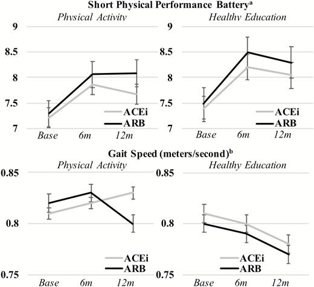

Graph of baseline, 6 and 12 months follow-up short physical performance battery (SPPB) and gait speed measures testing the effect of the trial intervention, treatment, and the interaction of intervention and treatment. <sup>**a**</sup>Short physical performance batter (SPPB) range from 0 to 12 points.

<sup>b</sup>Gait speed measured during 400 m walk test or proxy measures.

Note: Follow-up occurred at baseline visit, 6 months (6 m) and 12 months (12 m). Panels A/B: SPPB score by intervention arm and by treatment (unadjusted): Treatment × intervention (*p* = .298); treatment only (*p* = .478); intervention only (*p = .*002). Panels A/B: SPPB score by intervention arm and by treatment (IPTW-adjusted): Treatment × intervention (*p* = .443); treatment only (*p* = .541); intervention only (*p* = .012). Panels C/D: gait speed by intervention arm and by treatment (unadjusted): Treatment × intervention (*p* = .140); treatment only (*p* = .376); intervention only (*p* < .001). Panels C/D: gait speed by intervention arm and by treatment (unadjusted): Treatment × intervention (*p* = .244); treatment only (*p* = .179); intervention only (*p* < .001). All analyses conducted using analysis of covariance repeated measures.

## Discussion

Overall, we observed a lower rate of MMD (28% reduction) and persistent MMD (35% reduction) in participants using ARBs than those using ACEis, which remained after adjustment for baseline factors utilizing IPTW balancing techniques. The interaction terms between medication groups and intervention arms were nonsignificant for MMD outcomes, which suggest the observed associations were not mediated through synergism with the PA intervention as hypothesized but are independent effects that may be attributed to several hypothesized physiological pathways.

ACEis and ARBs are first-line treatment options for hypertension, prevention of cardiovascular disease, and renoprotection with mechanisms of action along the renin–angiotensin system. Recent evidence suggests that ACEis may have secondary effects on physical functioning (2,5), possibly due to reductions in chronic, low-grade inflammation, which impairs muscle function and is an independent risk factor for disability and mobility impairment (29). ARBs may have similar reductive effects on inflammatory markers but with better tolerability and safety; thus, investigation of the relative effects between these two interchangeable drug classes could have implications for prescribing in older adults common indications. Compared with other outcomes measured, the 400 m walk test may capture a more sustained, aerobic activity and was the only outcome with significant findings for the direct comparison of ARBs to ACEis. This difference in protection against MMD, but not other measures, could be attributed to evidence that ARBs may be uniquely neuroprotective in addition to other effects due to activation of proliferator-activated receptor-gamma or effects on aerobic activity and endurance through pathways not yet identified (16–18).

ACEis and ARBs have both been postulated as therapeutic options for preventing sarcopenia, protecting functional status, and delaying age-related cognitive decline (4,29). To the best of our knowledge, this is the first study to directly compare associations between ARBs and ACEis on the risk of MMD and physical functioning outcomes. In the LIFE trial and other studies, ACEis have been shown to be protective for mobility-related outcomes in older adults (2,5,29). Thus, relative findings for ARBs protecting against MMD results should be interpreted to be an effect beyond that already observed for ACEi, that is, both ACEis and ARBs should be considered as potentially protective with differential effects and pathways. Similar to prior analyses, both medication groups did not demonstrate a significant interaction with the PA intervention, suggesting that these benefits can be realized without further intervention.

The analytical approach in this study differed from prior studies that examined the associations of antihypertensive medications versus non-users as the current design should help mitigate indication bias or healthy user effects, which could account for reasons participants used one medication over the other or no medications at all (2,5). These common biases are greatly reduced when two interchangeable medications are compared; however, the potential for residual confounding persists. Notable differences were observed at baseline including black race and female sex, which are known channeling factors to ARBs given higher incidence of adverse effects of ACEi in these groups. However, race- and sex-stratified post hoc sensitivity analyses did not differ from the primary analyses.

The findings from this analysis showing ARBs may have added value in preventing mobility disability in an older population may help guide strategic prescribing decisions for older adults, especially those at risk for mobility, disability, and loss of physical independence. In practice, ARBs could be preferentially selected over ACEis for the treatment of hypertension, cardiovascular disease, or diabetes in older adults given these secondary benefits or be used independently to help preserve mobility. Further exploration of mechanistic pathways leading to the preservation of mobility unique to ARBs is needed to explain the observations in this study.

### Limitations

This study was a post hoc subgroup analysis of the LIFE trial, which was not powered to detect the influence of medications on outcomes. Overall estimates of the PA versus HE intervention were consistent with the original trial for these subgroups of patients using either ACEis or ARBs. More modest effects of medication influence on these outcomes may not be detectable using these data; however, we did observe statistical differences for the primary MMD and persistent MMD outcomes. Post hoc power calculations for the survival analysis showed power of more than 0.80 for all outcomes when accounting for follow-up and accrual time. Participants were not randomly assigned ACEi and ARB treatment and it is commonly known that observational comparisons between medications are subject to indication bias. However, by comparing medications that are therapeutically interchangeable, this bias is reduced. In addition, most baseline measures were similar between users of these medications and robust IPTW adjustment techniques were used to further balance these measured confounders. Medication use was measured only at baseline and at 12 months follow-up for LIFE participants and we used this information to determine exposure or discontinuation of treatment. This could lead to exposure misclassification if patient adherence to medications is poor or if patients discontinued medications before the 12 months follow-up visits. Additional studies with more detailed medication use profiles are needed to assess this limitation. MMD and injurious falls are not all-encompassing outcome measures for disability and injury; however, these were primary and secondary outcomes in the LIFE trial and were objectively measured. Additional effects of both ACEi and ARBs on different measures of mobility, disability, and injury are needed to fully understand medication effects. The LIFE study cohort is representative of a sedentary older adult population with existing physical limitations. ACEis and ARBs are also indicated for the treatment of hypertension, secondary prevention of cardiovascular diseases, and in diabetes. These findings may not generalize to the overall older adult population such as those who are immobile or who have no physical limitations at baseline or with no indications for treatment with ACEis or ARBs. The results of this study should be considered hypothesis generating and not as confirmative as additional studies are needed to confirm these effects as well as to elucidate mechanistic pathways.

## Conclusions

In this secondary analysis of the LIFE cohort, ARBs users were associated with lower risk of incident MMD and persistent MMD outcomes compared to ACEi users, but these effects were not observed with other physical functioning measures or injurious falls. This study provides the first direct comparison of ARBs versus ACEi on mobility disability and suggests that, while both medications are known for their benefits on aging-related physical and cognitive decline, ARBs may have additional benefits. Given these medication groups are generally as therapeutic alternatives, ARBs could be strategically prescribed to older adults with therapeutic indications to reduce the risk of aging-related mobility disability in addition to their primary use. Evidence from randomized controlled trials are needed to validate these findings and to provide further evidence for using these medication classes as primary therapy options for aging-related disorders.

## Funding

This work received no direct funding. J.B. is funded by a Claude D. Pepper Older American Independence Centers Junior Scholar Award from the University of Florida Institute on Aging through support from the National Institute on Aging at the National Institutes of Health (P30AG028740). S.S. receives research funding from the National Heart, Lung, and Blood Institute at the National Institutes of Health (K01 HL138172). T.G. is the recipient of an Academic Leadership Award (K07AG043587) from the National Institute on Aging at the National Institutes of Health and is supported by the Yale Claude D. Pepper Older Americans Independence Center (P30AG21342). T.B. was partially supported by National Institutes of Health grant R01AG056769. The LIFE study was funded by National Institutes of Health grant UO1AG22376 and partially supported by the Claude D. Pepper Older Americans Independence Centers at the University of Florida (1 P30 AG028740), Wake Forest University (1 P30 AG21332), Tufts University (1P30AG031679), University of Pittsburgh (P30AG024827), and Yale University (P30AG021342) and the National Institutes of Health CTSA at Stanford University (UL1 RR025744), at University of Florida (U54RR025208) and at Yale University (UL1 TR000142). Tufts University was also supported by the Boston Rehabilitation Outcomes Center (1R24HD065688-01A1). Dr. Gill is the recipient of an Academic Leadership Award (K07AG043587) from the National Institute on Aging at the National Institutes of Health.

## Conflicts of interest

None.

## Acknowledgments

These results were presented as a poster during the Gerontological Society of America’s 70th Annual Scientific Meeting, Boston, Massachusetts, November 14–18, 2018.

## References

1.

Williamson

J

,

Pahor

M

.

Evidence regarding the benefits of physical exercise

.

Arch Intern Med

.

2010

;

170

:

124

–

125

. doi: 10.1001/archinternmed.2009.491

Google Scholar

[Crossref](http://dx.doi.org/10.1001/archinternmed.2009.491)

[Find in my library](https://ufl-flvc.primo.exlibrisgroup.com/openurl/01FALSC_UFL/01FALSC_UFL:UFL?rft_id=info%3Adoi%2F10.1001%2Farchinternmed.2009.491)

[PubMed](http://www.ncbi.nlm.nih.gov/pubmed/20101006)

[WorldCat](https://www.worldcat.org/search?q=ti:Evidence%20regarding%20the%20benefits%20of%20physical%20exercise&qt=advanced&dblist=638)

2.

Buford

TW

,

Miller

ME

,

Church

TS

, et al. ;

LIFE Study Research Group

.

Antihypertensive use and the effect of a physical activity intervention in the prevention of major mobility disability among older adults: the LIFE study

.

J Gerontol A Biol Sci Med Sci

.

2016

;

71

:

974

–

981

. doi: 10.1093/gerona/glv222

Google Scholar

[Crossref](http://dx.doi.org/10.1093/gerona/glv222)

[Find in my library](https://ufl-flvc.primo.exlibrisgroup.com/openurl/01FALSC_UFL/01FALSC_UFL:UFL?rft_id=info%3Adoi%2F10.1093%2Fgerona%2Fglv222)

[PubMed](http://www.ncbi.nlm.nih.gov/pubmed/26865496)

WorldCat

3.

Onder

G

,

Della Vedova

C

,

Landi

F

.

Validated treatments and therapeutics prospectives regarding pharmacological products for sarcopenia

.

J Nutr Health Aging

.

2009

;

13

:

746

–

756

. doi:10.1007/s12603-009-0209-4

Google Scholar

[Crossref](http://dx.doi.org/10.1007/s12603-009-0209-4)

[Find in my library](https://ufl-flvc.primo.exlibrisgroup.com/openurl/01FALSC_UFL/01FALSC_UFL:UFL?rft_id=info%3Adoi%2F10.1007%2Fs12603-009-0209-4)

[PubMed](http://www.ncbi.nlm.nih.gov/pubmed/19657562)

[WorldCat](https://www.worldcat.org/search?q=ti:Validated%20treatments%20and%20therapeutics%20prospectives%20regarding%20pharmacological%20products%20for%20sarcopenia&qt=advanced&dblist=638)

4.

Carter

CS

,

Onder

G

,

Kritchevsky

SB

,

Pahor

M

.

Angiotensin-converting enzyme inhibition intervention in elderly persons: effects on body composition and physical performance

.

J Gerontol A Biol Sci Med Sci

.

2005

;

60

:

1437

–

1446

. doi:10.1093/gerona/60.11.1437

Google Scholar

[Crossref](http://dx.doi.org/10.1093/gerona/60.11.1437)

[Find in my library](https://ufl-flvc.primo.exlibrisgroup.com/openurl/01FALSC_UFL/01FALSC_UFL:UFL?rft_id=info%3Adoi%2F10.1093%2Fgerona%2F60.11.1437)

[PubMed](http://www.ncbi.nlm.nih.gov/pubmed/16339331)

WorldCat

5.

Buford

TW

,

Manini

TM

,

Hsu

FC

, et al.

Angiotensin-converting enzyme inhibitor use by older adults is associated with greater functional responses to exercise

.

J Am Geriatr Soc

.

2012

;

60

:

1244

–

1252

. doi: 10.1111/j.1532-5415.2012.04045.x

Google Scholar

[Crossref](http://dx.doi.org/10.1111/jgs.2012.60.issue-7)

[Find in my library](https://ufl-flvc.primo.exlibrisgroup.com/openurl/01FALSC_UFL/01FALSC_UFL:UFL?rft_id=info%3Adoi%2F10.1111%2Fjgs.2012.60.issue-7)

[PubMed](http://www.ncbi.nlm.nih.gov/pubmed/22726232)

[WorldCat](https://www.worldcat.org/search?q=ti:Angiotensin-converting%20enzyme%20inhibitor%20use%20by%20older%20adults%20is%20associated%20with%20greater%20functional%20responses%20to%20exercise&qt=advanced&dblist=638)

6.

Di Bari

M

,

van de Poll-Franse

LV

,

Onder

G

, et al. ;

Health, Aging and Body Composition Study

.

Antihypertensive medications and differences in muscle mass in older persons: the health, aging and body composition study

.

J Am Geriatr Soc

.

2004

;

52

:

961

–

966

. doi: 10.1111/j.1532-5415.2004.52265.x

Google Scholar

[Crossref](http://dx.doi.org/10.1111/jgs.2004.52.issue-6)

[Find in my library](https://ufl-flvc.primo.exlibrisgroup.com/openurl/01FALSC_UFL/01FALSC_UFL:UFL?rft_id=info%3Adoi%2F10.1111%2Fjgs.2004.52.issue-6)

[PubMed](http://www.ncbi.nlm.nih.gov/pubmed/15161462)

WorldCat

7.

Onder

G

,

Penninx

BW

,

Balkrishnan

R

, et al.

Relation between use of angiotensin-converting enzyme inhibitors and muscle strength and physical function in older women: an observational study

.

Lancet

.

2002

;

359

:

926

–

930

. doi:10.1016/S0140-6736(02)08024-8

Google Scholar

Crossref

Find in my library

[PubMed](http://www.ncbi.nlm.nih.gov/pubmed/11918911)

WorldCat

8.

Madej

A

,

Buldak

L

,

Basiak

M

,

Szkrobka

W

,

Dulawa

A

,

Okopien

B

.

The effects of 1 month antihypertensive treatment with perindopril, bisoprolol or both on the ex vivo ability of monocytes to secrete inflammatory cytokines

.

Int J Clin Pharmacol Ther

.

2009

;

47

:

686

–

694

. doi:10.5414/CPP47686

Google Scholar

[Crossref](http://dx.doi.org/10.5414/CPP47686)

[Find in my library](https://ufl-flvc.primo.exlibrisgroup.com/openurl/01FALSC_UFL/01FALSC_UFL:UFL?rft_id=info%3Adoi%2F10.5414%2FCPP47686)

[PubMed](http://www.ncbi.nlm.nih.gov/pubmed/19840533)

WorldCat

9.

Trevelyan

J

,

Brull

DJ

,

Needham

EW

,

Montgomery

HE

,

Morris

A

,

Mattu

RK

.

Effect of enalapril and losartan on cytokines in patients with stable angina pectoris awaiting coronary artery bypass grafting and their interaction with polymorphisms in the interleukin-6 gene

.

Am J Cardiol

.

2004

;

94

:

564

–

569

. doi: 10.1016/j.amjcard.2004.05.017

Google Scholar

[Crossref](http://dx.doi.org/10.1016/j.amjcard.2004.05.017)

[Find in my library](https://ufl-flvc.primo.exlibrisgroup.com/openurl/01FALSC_UFL/01FALSC_UFL:UFL?rft_id=info%3Adoi%2F10.1016%2Fj.amjcard.2004.05.017)

[PubMed](http://www.ncbi.nlm.nih.gov/pubmed/15342284)

WorldCat

10.

Sumukadas

D

,

Witham

MD

,

Struthers

AD

,

McMurdo

ME

.

Effect of perindopril on physical function in elderly people with functional impairment: a randomized controlled trial

.

CMAJ

.

2007

;

177

:

867

–

874

. doi: 10.1503/cmaj.061339

Google Scholar

[Crossref](http://dx.doi.org/10.1503/cmaj.061339)

[Find in my library](https://ufl-flvc.primo.exlibrisgroup.com/openurl/01FALSC_UFL/01FALSC_UFL:UFL?rft_id=info%3Adoi%2F10.1503%2Fcmaj.061339)

[PubMed](http://www.ncbi.nlm.nih.gov/pubmed/17923654)

WorldCat

11.

Touyz

RM

,

Savoia

C

,

He

Y

, et al.

Increased inflammatory biomarkers in hypertensive type 2 diabetic patients: improvement after angiotensin II type 1 receptor blockade

.

J Am Soc Hypertens

.

2007

;

1

:

189

–

199

. doi: 10.1016/j.jash.2007.01.009

Google Scholar

[Crossref](http://dx.doi.org/10.1016/j.jash.2007.01.009)

[Find in my library](https://ufl-flvc.primo.exlibrisgroup.com/openurl/01FALSC_UFL/01FALSC_UFL:UFL?rft_id=info%3Adoi%2F10.1016%2Fj.jash.2007.01.009)

[PubMed](http://www.ncbi.nlm.nih.gov/pubmed/20409851)

WorldCat

12.

Verma

S

,

Mamdani

MM

,

Al-Omran

M

,

Melo

M

,

Rouleau

JL

.

Angiotensin receptor blockers vs. angiotensin converting enzyme inhibitors and acute coronary syndrome outcomes in elderly patients: a population-based cohort study (UMPIRE study results)

.

J Am Soc Hypertens

.

2007

;

1

:

286

–

294

. doi: 10.1016/j.jash.2007.05.003

Google Scholar

[Crossref](http://dx.doi.org/10.1016/j.jash.2007.05.003)

[Find in my library](https://ufl-flvc.primo.exlibrisgroup.com/openurl/01FALSC_UFL/01FALSC_UFL:UFL?rft_id=info%3Adoi%2F10.1016%2Fj.jash.2007.05.003)

[PubMed](http://www.ncbi.nlm.nih.gov/pubmed/20409860)

WorldCat

13.

Xu

R

,

Sun

S

,

Huo

Y

,

Yun

L

,

Huang

S

,

Li

G

, et al.

Effects of ACEIs versus ARBs on proteinuria or albuminuria in primary hypertension: a meta-analysis of randomized trials

.

Medicine (Baltim)

..

2015

;

94

:

e1560

. doi:10.1097/MD.0000000000001560

Google Scholar

[Crossref](http://dx.doi.org/10.1097/MD.0000000000001560)

[Find in my library](https://ufl-flvc.primo.exlibrisgroup.com/openurl/01FALSC_UFL/01FALSC_UFL:UFL?rft_id=info%3Adoi%2F10.1097%2FMD.0000000000001560)

WorldCat

14.

Whelton

PK

,

Carey

RM

,

Aronow

WS

, et al.

2017 ACC/AHA/AAPA/ABC/ACPM/AGS/APhA/ASH/ASPC/NMA/PCNA Guideline for the prevention, detection, evaluation, and management of high blood pressure in adults: a report of the American College of Cardiology/American Heart Association Task Force on Clinical Practice Guidelines

.

J Am Coll Cardiol

.

2018

;

71

:

e127

–

e248

. doi: 10.1016/j.jacc.2017.11.006

Google Scholar

[Crossref](http://dx.doi.org/10.1016/j.jacc.2017.11.006)

[Find in my library](https://ufl-flvc.primo.exlibrisgroup.com/openurl/01FALSC_UFL/01FALSC_UFL:UFL?rft_id=info%3Adoi%2F10.1016%2Fj.jacc.2017.11.006)

[PubMed](http://www.ncbi.nlm.nih.gov/pubmed/29146535)

WorldCat

15.

Messerli

FH

,

Bangalore

S

,

Bavishi

C

,

Rimoldi

SF

.

Angiotensin-converting enzyme inhibitors in hypertension: to use or not to use?

J Am Coll Cardiol

.

2018

;

71

:

1474

–

1482

. doi: 10.1016/j.jacc.2018.01.058

Google Scholar

[Crossref](http://dx.doi.org/10.1016/j.jacc.2018.01.058)

[Find in my library](https://ufl-flvc.primo.exlibrisgroup.com/openurl/01FALSC_UFL/01FALSC_UFL:UFL?rft_id=info%3Adoi%2F10.1016%2Fj.jacc.2018.01.058)

[PubMed](http://www.ncbi.nlm.nih.gov/pubmed/29598869)

[WorldCat](https://www.worldcat.org/search?q=ti:Angiotensin-converting%20enzyme%20inhibitors%20in%20hypertension%3A%20to%20use%20or%20not%20to%20use%3F&qt=advanced&dblist=638)

16.

Mogi

M

,

Li

JM

,

Tsukuda

K

, et al.

Telmisartan prevented cognitive decline partly due to PPAR-gamma activation

.

Biochem Biophys Res Commun

.

2008

;

375

:

446

–

449

. doi: 10.1016/j.bbrc.2008.08.032

Google Scholar

[Crossref](http://dx.doi.org/10.1016/j.bbrc.2008.08.032)

[Find in my library](https://ufl-flvc.primo.exlibrisgroup.com/openurl/01FALSC_UFL/01FALSC_UFL:UFL?rft_id=info%3Adoi%2F10.1016%2Fj.bbrc.2008.08.032)

[PubMed](http://www.ncbi.nlm.nih.gov/pubmed/18715543)

[WorldCat](https://www.worldcat.org/search?q=ti:Telmisartan%20prevented%20cognitive%20decline%20partly%20due%20to%20PPAR-gamma%20activation&qt=advanced&dblist=638)

17.

Marshall

TG

,

Lee

RE

,

Marshall

FE

.

Common angiotensin receptor blockers may directly modulate the immune system via VDR, PPAR and CCR2b

.

Theor Biol Med Model

.

2006

;

3

:

1

. doi: 10.1186/1742-4682-3-1

Google Scholar

[Crossref](http://dx.doi.org/10.1186/1742-4682-3-1)

[Find in my library](https://ufl-flvc.primo.exlibrisgroup.com/openurl/01FALSC_UFL/01FALSC_UFL:UFL?rft_id=info%3Adoi%2F10.1186%2F1742-4682-3-1)

[PubMed](http://www.ncbi.nlm.nih.gov/pubmed/16403216)

[WorldCat](https://www.worldcat.org/search?q=ti:Common%20angiotensin%20receptor%20blockers%20may%20directly%20modulate%20the%20immune%20system%20via%20VDR%2C%20PPAR%20and%20CCR2b&qt=advanced&dblist=638)

18.

Villapol

S

,

Saavedra

JM

.

Neuroprotective effects of angiotensin receptor blockers

.

Am J Hypertens

.

2015

;

28

:

289

–

299

. doi: 10.1093/ajh/hpu197

Google Scholar

[Crossref](http://dx.doi.org/10.1093/ajh/hpu197)

[Find in my library](https://ufl-flvc.primo.exlibrisgroup.com/openurl/01FALSC_UFL/01FALSC_UFL:UFL?rft_id=info%3Adoi%2F10.1093%2Fajh%2Fhpu197)

[PubMed](http://www.ncbi.nlm.nih.gov/pubmed/25362113)

[WorldCat](https://www.worldcat.org/search?q=ti:Neuroprotective%20effects%20of%20angiotensin%20receptor%20blockers&qt=advanced&dblist=638)

19.

Pahor

M

,

Guralnik

JM

,

Ambrosius

WT

, et al. ;

LIFE study investigators

.

Effect of structured physical activity on prevention of major mobility disability in older adults: the LIFE study randomized clinical trial

.

JAMA

.

2014

;

311

:

2387

–

2396

. doi: 10.1001/jama.2014.5616

Google Scholar

[Crossref](http://dx.doi.org/10.1001/jama.2014.5616)

[Find in my library](https://ufl-flvc.primo.exlibrisgroup.com/openurl/01FALSC_UFL/01FALSC_UFL:UFL?rft_id=info%3Adoi%2F10.1001%2Fjama.2014.5616)

[PubMed](http://www.ncbi.nlm.nih.gov/pubmed/24866862)

WorldCat

20.

Fielding

RA

,

Rejeski

WJ

,

Blair

S

, et al. ;

LIFE Research Group

.

The lifestyle interventions and independence for elders study: design and methods

.

J Gerontol A Biol Sci Med Sci

.

2011

;

66

:

1226

–

1237

. doi: 10.1093/gerona/glr123

Google Scholar

[Crossref](http://dx.doi.org/10.1093/gerona/glr123)

[Find in my library](https://ufl-flvc.primo.exlibrisgroup.com/openurl/01FALSC_UFL/01FALSC_UFL:UFL?rft_id=info%3Adoi%2F10.1093%2Fgerona%2Fglr123)

[PubMed](http://www.ncbi.nlm.nih.gov/pubmed/21825283)

[WorldCat](https://www.worldcat.org/search?q=ti:The%20lifestyle%20interventions%20and%20independence%20for%20elders%20study%3A%20design%20and%20methods&qt=advanced&dblist=638)

21.

Marsh

AP

,

Lovato

LC

,

Glynn

NW

, et al. ;

LIFE Study Research Group

.

Lifestyle interventions and independence for elders study: recruitment and baseline characteristics

.

J Gerontol A Biol Sci Med Sci

.

2013

;

68

:

1549

–

1558

. doi: 10.1093/gerona/glt064

Google Scholar

[Crossref](http://dx.doi.org/10.1093/gerona/glt064)

[Find in my library](https://ufl-flvc.primo.exlibrisgroup.com/openurl/01FALSC_UFL/01FALSC_UFL:UFL?rft_id=info%3Adoi%2F10.1093%2Fgerona%2Fglt064)

[PubMed](http://www.ncbi.nlm.nih.gov/pubmed/23716501)

[WorldCat](https://www.worldcat.org/search?q=ti:Lifestyle%20interventions%20and%20independence%20for%20elders%20study%3A%20recruitment%20and%20baseline%20characteristics&qt=advanced&dblist=638)

22.

Rejeski

WJ

,

Axtell

R

,

Fielding

R

, et al. ;

LIFE Study Investigator Group

.

Promoting physical activity for elders with compromised function: the lifestyle interventions and independence for elders (LIFE) study physical activity intervention

.

Clin Interv Aging

.

2013

;

8

:

1119

–

1131

. doi: 10.2147/CIA.S49737

Google Scholar

[Crossref](http://dx.doi.org/10.2147/CIA)

[Find in my library](https://ufl-flvc.primo.exlibrisgroup.com/openurl/01FALSC_UFL/01FALSC_UFL:UFL?rft_id=info%3Adoi%2F10.2147%2FCIA)

[PubMed](http://www.ncbi.nlm.nih.gov/pubmed/24049442)

WorldCat

23.

Guralnik

JM

,

Simonsick

EM

,

Ferrucci

L

, et al.

A short physical performance battery assessing lower extremity function: association with self-reported disability and prediction of mortality and nursing home admission

.

J Gerontol

.

1994

;

49

:

M85

–

M94

. doi:10.1093/geronj/49.2.M85

Google Scholar

[Crossref](http://dx.doi.org/10.1093/geronj/49.2.M85)

[Find in my library](https://ufl-flvc.primo.exlibrisgroup.com/openurl/01FALSC_UFL/01FALSC_UFL:UFL?rft_id=info%3Adoi%2F10.1093%2Fgeronj%2F49.2.M85)

[PubMed](http://www.ncbi.nlm.nih.gov/pubmed/8126356)

WorldCat

24.

Gill

TM

,

Pahor

M

,

Guralnik

JM

, et al. ;

LIFE Study Investigators

.

Effect of structured physical activity on prevention of serious fall injuries in adults aged 70-89: randomized clinical trial (LIFE Study)

.

BMJ

.

2016

;

352

:

i245

. doi: 10.1136/bmj.i245

Google Scholar

[Crossref](http://dx.doi.org/10.1136/bmj.i245)

[Find in my library](https://ufl-flvc.primo.exlibrisgroup.com/openurl/01FALSC_UFL/01FALSC_UFL:UFL?rft_id=info%3Adoi%2F10.1136%2Fbmj.i245)

[PubMed](http://www.ncbi.nlm.nih.gov/pubmed/26842425)

WorldCat

25.

Glynn

RJ

,

Schneeweiss

S

,

Stürmer

T

.

Indications for propensity scores and review of their use in pharmacoepidemiology

.

Basic Clin Pharmacol Toxicol

.

2006

;

98

:

253

–

259

. doi: 10.1111/j.1742-7843.2006.pto_293.x

Google Scholar

[Crossref](http://dx.doi.org/10.1111/pto.2006.98.issue-3)

[Find in my library](https://ufl-flvc.primo.exlibrisgroup.com/openurl/01FALSC_UFL/01FALSC_UFL:UFL?rft_id=info%3Adoi%2F10.1111%2Fpto.2006.98.issue-3)

[PubMed](http://www.ncbi.nlm.nih.gov/pubmed/16611199)

[WorldCat](https://www.worldcat.org/search?q=ti:Indications%20for%20propensity%20scores%20and%20review%20of%20their%20use%20in%20pharmacoepidemiology&qt=advanced&dblist=638)

26.

Lunceford

JK

,

Davidian

M

.

Stratification and weighting via the propensity score in estimation of causal treatment effects: a comparative study

.

Stat Med

.

2004

;

23

:

2937

–

2960

. doi: 10.1002/sim.1903

Google Scholar

[Crossref](http://dx.doi.org/10.1002/sim.v23:19)

[Find in my library](https://ufl-flvc.primo.exlibrisgroup.com/openurl/01FALSC_UFL/01FALSC_UFL:UFL?rft_id=info%3Adoi%2F10.1002%2Fsim.v23:19)

[PubMed](http://www.ncbi.nlm.nih.gov/pubmed/15351954)

[WorldCat](https://www.worldcat.org/search?q=ti:Stratification%20and%20weighting%20via%20the%20propensity%20score%20in%20estimation%20of%20causal%20treatment%20effects%3A%20a%20comparative%20study&qt=advanced&dblist=638)

27.

Austin

PC

,

Schuster

T

.

The performance of different propensity score methods for estimating absolute effects of treatments on survival outcomes: a simulation study

.

Stat Methods Med Res

..

2014

. doi:0962280213519716

Google Scholar

Find in my library

WorldCat

28.

Austin

PC

.

Balance diagnostics for comparing the distribution of baseline covariates between treatment groups in propensity-score matched samples

.

Stat Med

.

2009

;

28

:

3083

–

3107

. doi: 10.1002/sim.3697

Google Scholar

[Crossref](http://dx.doi.org/10.1002/sim.3697)

[Find in my library](https://ufl-flvc.primo.exlibrisgroup.com/openurl/01FALSC_UFL/01FALSC_UFL:UFL?rft_id=info%3Adoi%2F10.1002%2Fsim.3697)

[PubMed](http://www.ncbi.nlm.nih.gov/pubmed/19757444)

WorldCat

29.

Simon

CB

,

Lee-McMullen

B

,

Phelan

D

,

Gilkes

J

,

Carter

CS

,

Buford

TW

.

The renin-angiotensin system and prevention of age-related functional decline: where are we now?

Age (Dordr)

.

2015

;

37

:

9753

. doi: 10.1007/s11357-015-9753-5

Google Scholar

[Crossref](http://dx.doi.org/10.1007/s11357-015-9753-5)

[Find in my library](https://ufl-flvc.primo.exlibrisgroup.com/openurl/01FALSC_UFL/01FALSC_UFL:UFL?rft_id=info%3Adoi%2F10.1007%2Fs11357-015-9753-5)

[PubMed](http://www.ncbi.nlm.nih.gov/pubmed/25663422)

[WorldCat](https://www.worldcat.org/search?q=ti:The%20renin-angiotensin%20system%20and%20prevention%20of%20age-related%20functional%20decline%3A%20where%20are%20we%20now%3F&qt=advanced&dblist=638)

[figure not shown]

[figure not shown]